# Lab 8: Introduction to machine learning for Bioinformatics

## 2. PCA of RNA-seq data

### Part A

Download data from provided link.

```r
url2 <- "https://tinyurl.com/expression-CSV"
rna.data <- read.csv(url2, row.names=1)
head(rna.data)
```

```
##        wt1 wt2  wt3  wt4 wt5 ko1 ko2 ko3 ko4 ko5
## gene1  439 458  408  429 420  90  88  86  90  93
## gene2  219 200  204  210 187 427 423 434 433 426
## gene3 1006 989 1030 1017 973 252 237 238 226 210
## gene4  783 792  829  856 760 849 856 835 885 894
## gene5  181 249  204  244 225 277 305 272 270 279
## gene6  460 502  491  491 493 612 594 577 618 638
```

> **Q10.** How many genes and samples are in this data set?

```r
dim(rna.data)
```

```
## [1] 100  10
```

> **A10.** There are 100 genes and 10 samples in this data set.

Use PCA to plot the results.

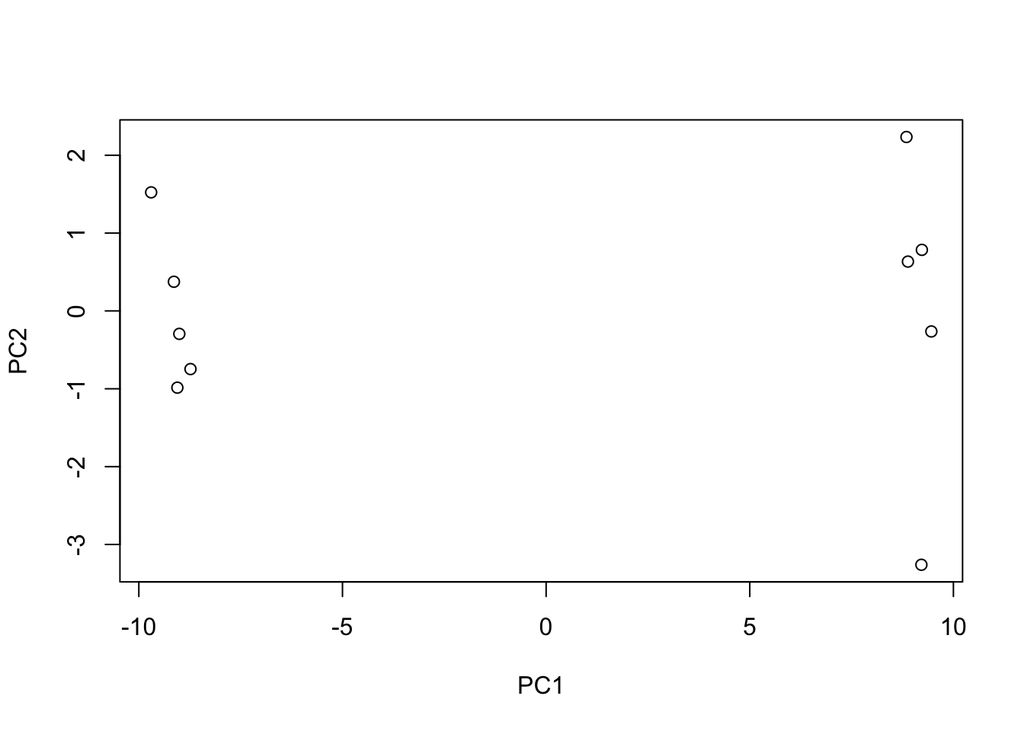

```r
# Take the transpose of our data.
pca <- prcomp( t(rna.data),
               scale=TRUE)

# Simple unpolished plot of PC1 and PC2
plot (pca$x[,1], pca$x[,2],
      xlab="PC1",
      ylab="PC2")
```

Examine summary of how much variation in the original data each PC accounts for.

```r
summary(pca)
```

```
## Importance of components:
##                           PC1    PC2     PC3     PC4     PC5     PC6     PC7
## Standard deviation     9.6237 1.5198 1.05787 1.05203 0.88062 0.82545 0.80111
## Proportion of Variance 0.9262 0.0231 0.01119 0.01107 0.00775 0.00681 0.00642
## Cumulative Proportion  0.9262 0.9493 0.96045 0.97152 0.97928 0.98609 0.99251
##                            PC8     PC9      PC10
## Standard deviation     0.62065 0.60342 3.348e-15
## Proportion of Variance 0.00385 0.00364 0.000e+00
## Cumulative Proportion  0.99636 1.00000 1.000e+00
```

Make a barplot summary of Proportion of Variance for Each PC using the plot() function.

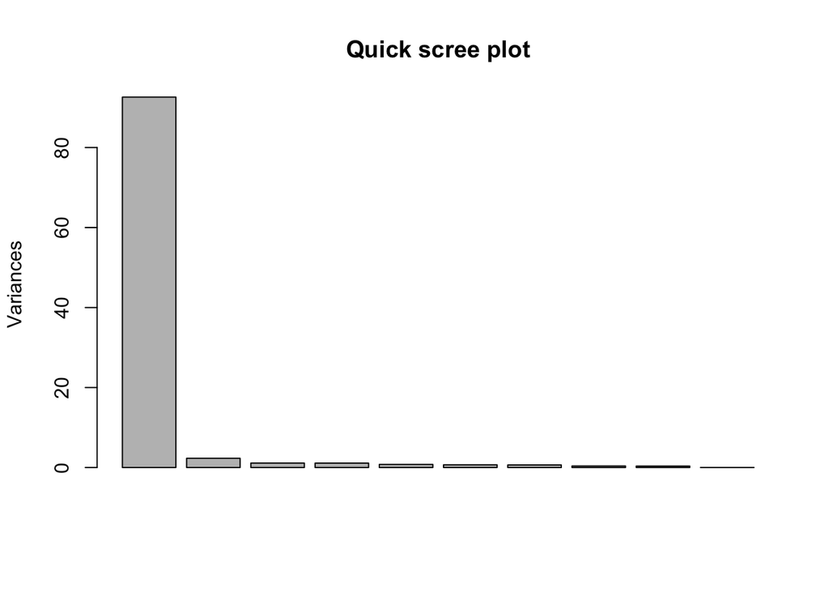

```r
plot(pca, main="Quick scree plot")
```

Make scree plot ourselves using square of pca$sdev (standard deviation)

```r
# Variance captured per PC
pca.var <- pca$sdev^2

# Percent variance is often more informative
pca.var.per <- round (pca.var/sum(pca.var)*100,1)
pca.var.per
```

```
##  [1] 92.6  2.3  1.1  1.1  0.8  0.7  0.6  0.4  0.4  0.0
```

Make a bar plot with pca.var.per.

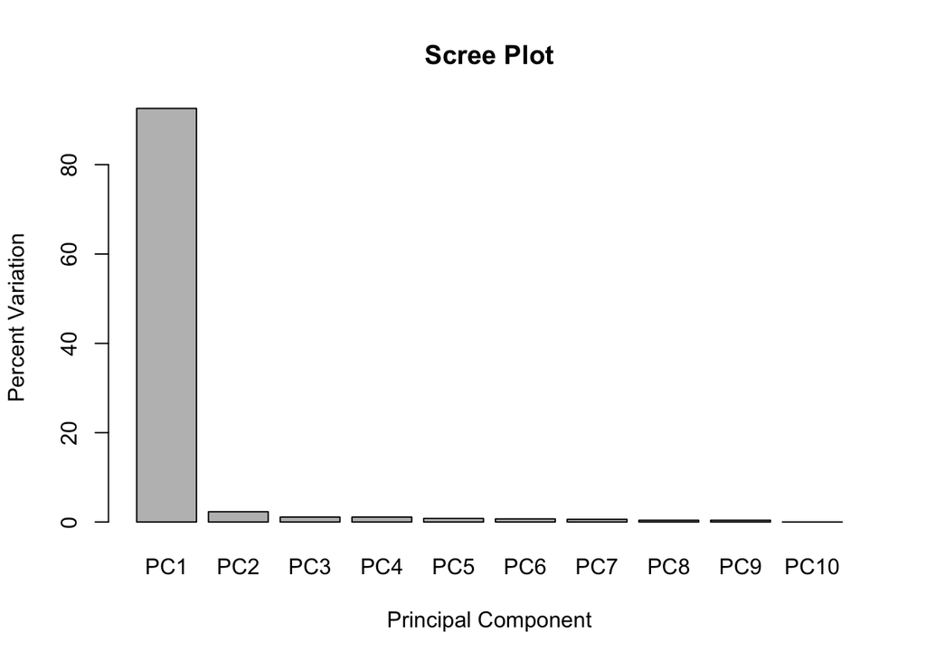

```r
barplot (pca.var.per,
         main="Scree Plot",
         names.arg = paste0 ("PC", 1:10),
         xlab="Principal Component",
         ylab="Percent Variation")
```

Make PCA plot look nicer / be more useful.

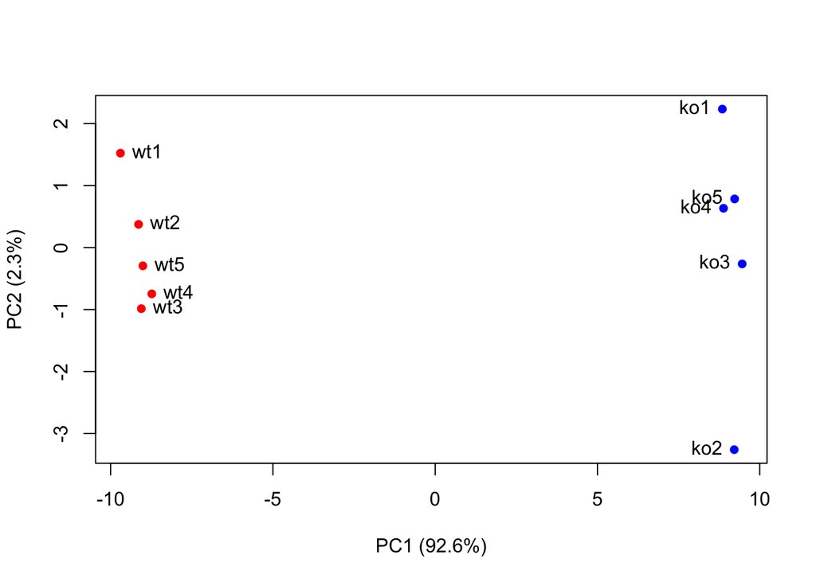

```r
# A vector of colors for wt and ko samples
colvec <- colnames (rna.data)
colvec[grep("wt", colvec)] <- "red"
colvec[grep("ko", colvec)] <- "blue"

plot(pca$x[,1], pca$x[,2],
     col=colvec,
     pch=16,
     xlab=paste0("PC1 (", pca.var.per[1], "%)"),
     ylab=paste0("PC2 (", pca.var.per[2], "%)")
)

text (pca$x[,1], pca$x[,2],
      labels=colnames(rna.data),
      pos=c(rep(4,5), rep(2,5))
)
```

### Part B: Using ggplot

Use ggplot & make a data.frame for the input from PCA results.

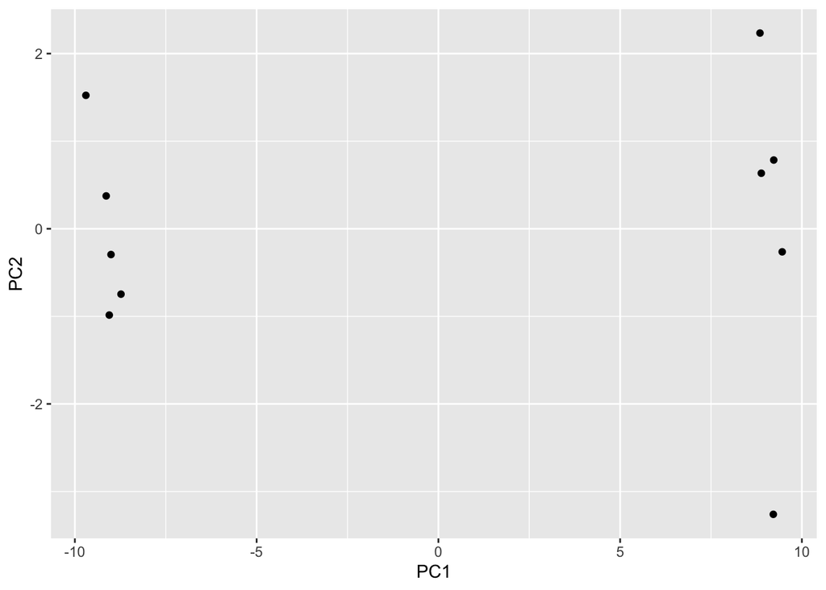

```r
library(ggplot2)

df <- as.data.frame(pca$x)

# Our first basic plot.
ggplot(df) +
  aes(PC1, PC2) +
  geom_point()
```

Adding aesthetics.

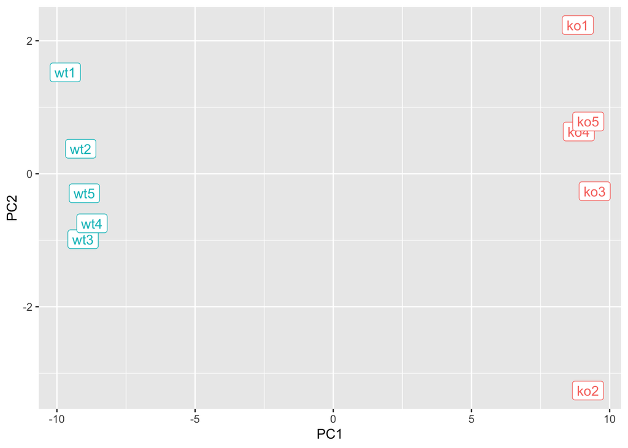

```r
# Add a 'wt' and 'ko' "condition" column
df$samples <- colnames(rna.data)
df$condition <- substr(colnames(rna.data), 1,2)

p <- ggplot(df) +
  aes(PC1, PC2, label=samples, col=condition) +
  geom_label(show.legend=FALSE)
p
```

More aesthetics.

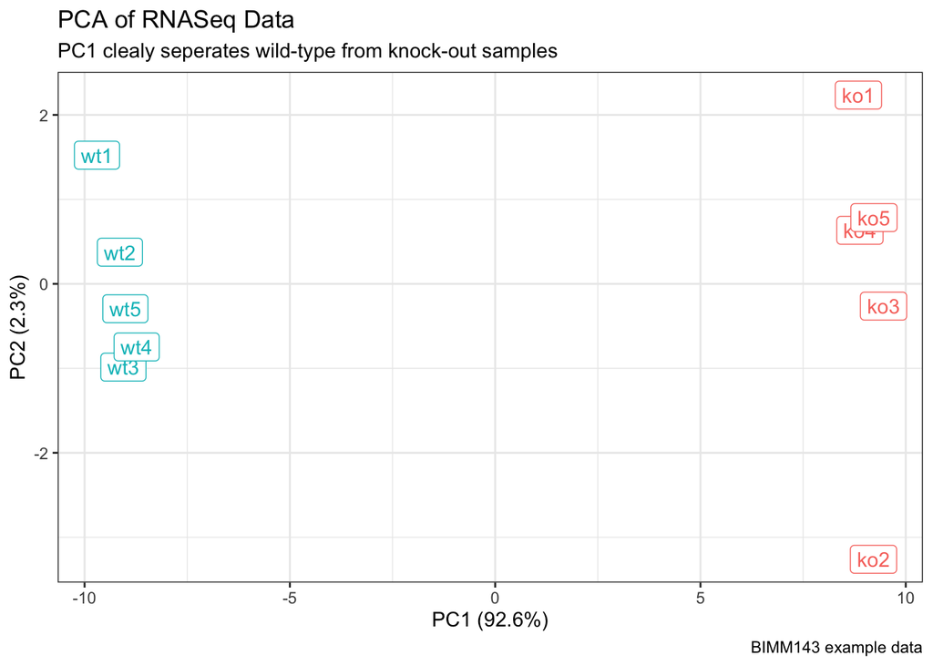

```r
p + labs(title="PCA of RNASeq Data",
       subtitle = "PC1 clealy seperates wild-type from knock-out samples",
       x=paste0("PC1 (", pca.var.per[1], "%)"),
       y=paste0("PC2 (", pca.var.per[2], "%)"),
       caption="BIMM143 example data") +
     theme_bw()
```

### Part C: Optional - Gene Loadings

List top 10 measurements (genes) that contribute most to PC1 (either positive or negative)

```r
loading_scores <- pca$rotation[,1]

## Find the top 10 measurements (genes) that contribute
## most to PC1 in either direction (+ or -)
gene_scores <- abs(loading_scores)
gene_score_ranked <- sort(gene_scores, decreasing=TRUE)

## show the names of the top 10 genes
top_10_genes <- names(gene_score_ranked[1:10])
top_10_genes
```

```
##  [1] "gene100" "gene66"  "gene45"  "gene68"  "gene98"  "gene60"  "gene21"
##  [8] "gene56"  "gene10"  "gene90"
```

## 3. Producing a PDF Report

See YAML header / current format.

## 4. Sync to GitHub

See my Github page: https://github.com/carolinemackey/bimm143